# ADSP 31006 Time Series Analysis and Forecasting

# Assignment #7 - ARIMAX and VAR

## Vishal Parameswaran

### Question 1:

Load the data and calculate the average cost of a night’s accommodation in Victoria each month (i.e.,Cost variable). 1. Plot the CPI and Cost time series. 2. Plot the Cost time series against the CPI time series and calculate the correlation between CPI and Cost.

Discuss your results and explain why the logarithms of both variables need to be taken before fitting any models. 3. Plot the $log(CPI)$ and $log(Cost)$ time series and calculate the correlation between the logarithms of both CPI and Cost.

Ans:

```r
load('motel.rda')

# Calculate the average cost per room night (in dollars)
cost.avg <- motel[,"Takings"] / motel[,"Roomnights"] * 1000
motel.new <- cbind(motel, cost.avg)
colnames(motel.new) <- c(colnames(motel), "Avg_Cost")

# Display the calculated average cost
motel.new
```

```
##          Roomnights Takings   CPI Avg_Cost
## Jan 1980     276986    7673  45.2 27.70176
## Feb 1980     260633    7472  45.2 28.66866
## Mar 1980     291551    8339  45.2 28.60220
## Apr 1980     275383    7805  46.6 28.34235
## May 1980     275302    7889  46.6 28.65580
## Jun 1980     231693    6619  46.6 28.56798
## Jul 1980     238829    6969  47.5 29.17987
## Aug 1980     274215    8186  47.5 29.85249
## Sep 1980     277808    8220  47.5 29.58878
## Oct 1980     299060    9074  48.5 30.34174
## Nov 1980     286629    8954  48.5 31.23899
## Dec 1980     232313    7138  48.5 30.72579
## Jan 1981     294053    8906  49.6 30.28706
## Feb 1981     267510    8490  49.6 31.73713
## Mar 1981     309739    9781  49.6 31.57820
## Apr 1981     280733    8789  50.7 31.30733
## May 1981     287298    9162  50.7 31.89023
## Jun 1981     235672    7430  50.7 31.52687
## Jul 1981     256449    8293  51.8 32.33781
## Aug 1981     288997    9653  51.8 33.40173
## Sep 1981     290789    9674  51.8 33.26811
## Oct 1981     321898   10841  54.1 33.67837
## Nov 1981     291834    9845  54.1 33.73493
## Dec 1981     241380    7935  54.1 32.87348
## Jan 1982     295469    9849  54.8 33.33345
## Feb 1982     258200    8977  54.8 34.76762
## Mar 1982     306102   10523  54.8 34.37743
## Apr 1982     281480    9536  56.1 33.87807
## May 1982     283101    9685  56.1 34.21041
## Jun 1982     237414    8067  56.1 33.97862
## Jul 1982     274834   10135  58.1 36.87681
## Aug 1982     299340   11074  58.1 36.99472
## Sep 1982     300383   11150  58.1 37.11928
## Oct 1982     340862   12616  59.6 37.01205
## Nov 1982     318794   12156  59.6 38.13121
## Dec 1982     265740    9903  59.6 37.26575
## Jan 1983     322656   11833  60.9 36.67373
## Feb 1983     281563   11135  60.9 39.54710
## Mar 1983     323461   12585  60.9 38.90732
```

[output cut: 132 more lines]

```
## Apr 1994     492071   39317 112.0 79.90107
## May 1994     421253   34095 112.0 80.93711
## Jun 1994     396682   32434 112.0 81.76323
## Jul 1994     428000   36323 112.2 84.86682
## Aug 1994     421900   36831 112.2 87.29794
## Sep 1994     465600   40515 112.2 87.01675
## Oct 1994     525793   46002 113.1 87.49070
## Nov 1994     499855   43871 113.1 87.76745
## Dec 1994     435287   37198 113.1 85.45626
## Jan 1995     479499   40722 115.0 84.92614
## Feb 1995     473027   41991 115.0 88.77083
## Mar 1995     554410   49186 115.0 88.71774
## Apr 1995     489574   42303 116.2 86.40777
## May 1995     462157   40750 116.2 88.17350
## Jun 1995     420331   37582 116.2 89.41049
```

The start date is Jan 1980 and the end date is June 1995.

1. Plot the CPI and Cost time series.

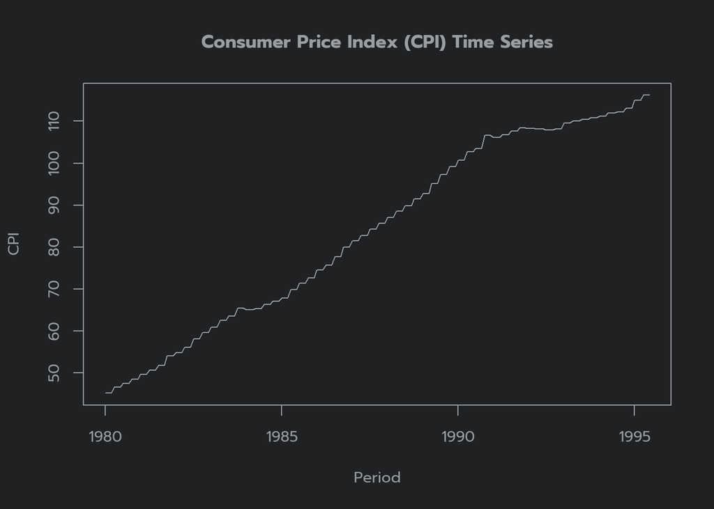

```r
motel.ts <- ts(motel.new, start = '1980', frequency = 12)
plot(motel.ts[,'CPI'], ylab="CPI", xlab="Period", main="Consumer Price Index (CPI) Time Series")
```

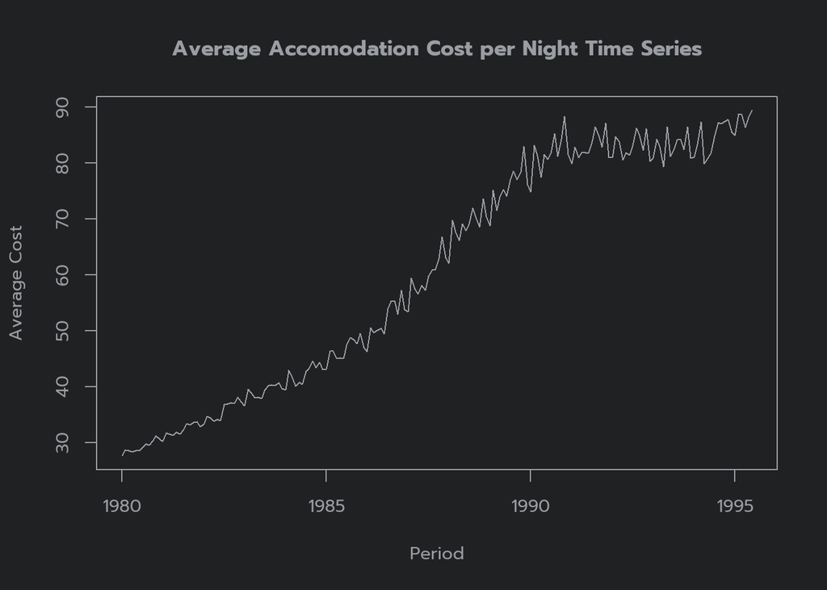

```r
plot(motel.ts[,'Avg_Cost'], ylab="Average Cost", xlab="Period", main="Average Accomodation Cost per Night Time Series")
```

2. Plot the Cost time series against the CPI time series and calculate the correlation between CPI and Cost.

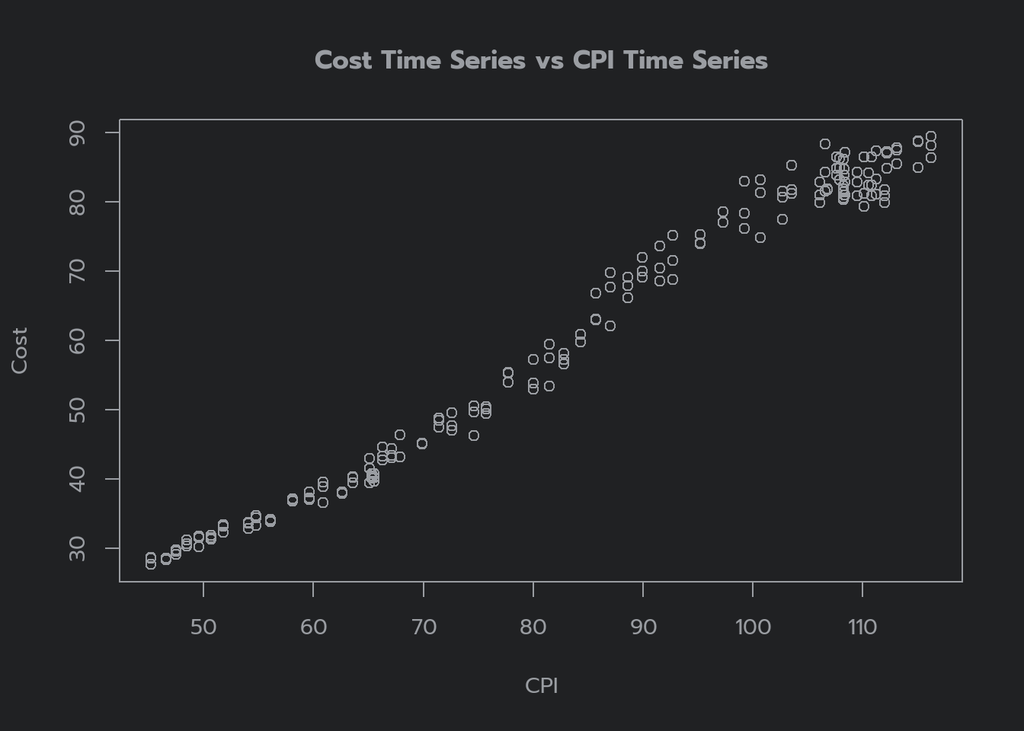

```r
plot(motel.ts[,'CPI'], motel.ts[,'Avg_Cost'], xlab = "CPI", ylab = "Cost", main='Cost Time Series vs CPI Time Series')
```

```r
cat("Correlation between CPI and Cost:", cor(motel.ts[,'CPI'], motel.ts[,'Avg_Cost']))
```

```
## Correlation between CPI and Cost: 0.9907186
```

Discuss your results and explain why the logarithms of both variables need to be taken before fitting any models.

In examining the time series plot of the Consumer Price Index (CPI), we observe a distinct trend. Furthermore, the average cost time series exhibits both a trend and seasonal patterns, indicating that the data is non-stationary. When comparing the time series of Cost and CPI, the inconsistency in data variance further confirms the non-stationary nature of our data. The strong correlation values observed point to a significant linear relationship between the logarithms of CPI and Cost. Transforming time series data with logarithms is known to reduce variability and encourage stationarity, thereby improving the accuracy of time series modeling. Therefore, in our analysis, applying logarithmic transformations to both the CPI and Cost time series could be advantageous.

3. Plot the log(CPI) and log(Cost) time series and calculate the correlation between the logarithms of both CPI and Cost.

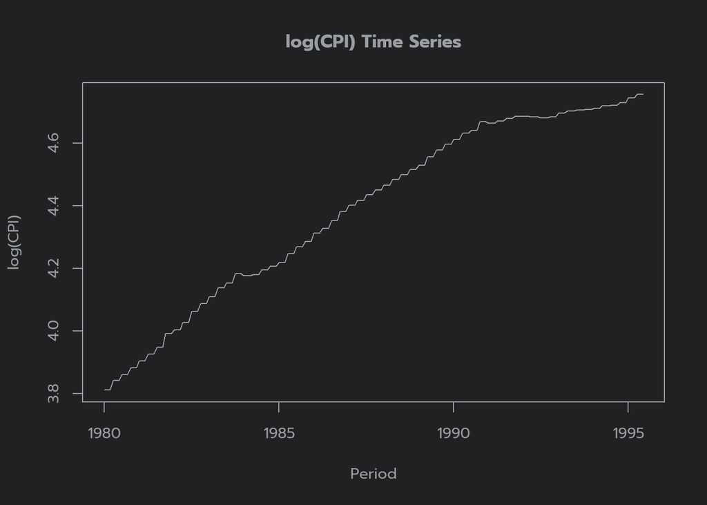

```r
plot(log(motel.ts[,'CPI']), ylab="log(CPI)", xlab="Period", main="log(CPI) Time Series")
```

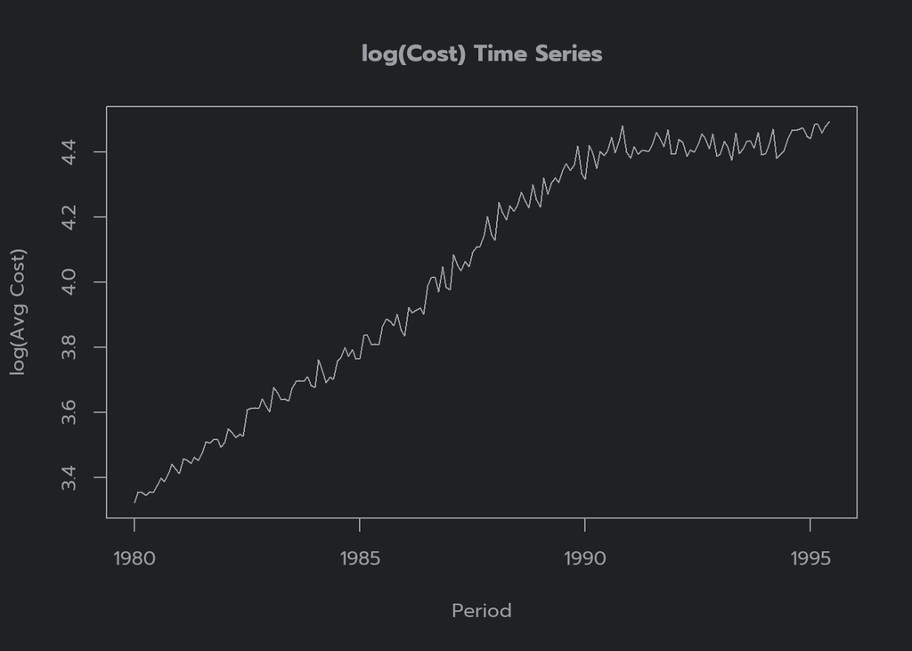

```r
plot(log(motel.ts[,'Avg_Cost']), ylab="log(Avg Cost)", xlab="Period", main="log(Cost) Time Series")
```

```r
cat("Correlation: CPI / Cost after log transformation:", cor(log(motel.ts[,'CPI']), log(motel.ts[,'Avg_Cost'])))
```

```
## Correlation: CPI / Cost after log transformation: 0.9929902
```

A significant positive correlation is evident between CPI and Cost, which remains high both before and after the log transformation is applied. This strong correlation implies a robust relationship between CPI and Cost. The application of the log transformation has served to stabilize the variance and linearize any non-linear trends present in the initial data, resulting in a marginally increased correlation.

### Question 2:

1. Use the linear model with time series components function tslm() to fit a linear model to the $log(Cost)$ time series as a function of the $log(CPI)$ time series (i.e., CPI ➔ Independent variable, Cost➔ Dependent variable).
2. Plot $log(CPI)$ against $log(Cost)$ and the fitted trend.
3. Use the summary() function to summarize the generated model , and the checkresiduals() function to evaluate the residuals. Discuss your results.

Ans:

1. Use the linear model with time series components function tslm() to fit a linear model to the log(Cost) time series as a function of the log(CPI) time series (i.e., CPI➔Independent variable, Cost➔Dependent variable).

```r
model.linear <- tslm(log(motel.ts[,'Avg_Cost']) ~ log(motel.ts[,'CPI']))
```

2. Plot log(CPI) against log(Cost) and the fitted trend.

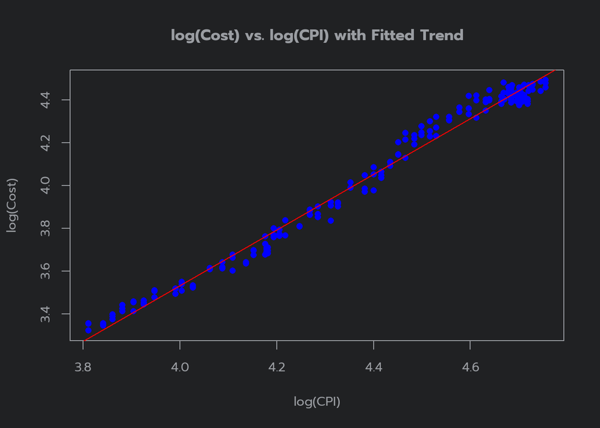

```r
plot(log(motel.ts[,'CPI']), log(motel.ts[,'Avg_Cost']), pch = 16, col = "blue", xlab = "log(CPI)", ylab = "log(Cost)", main = "log(Cost) vs. log(CPI) with Fitted Trend")

# Add the fitted trend line
abline(model.linear$coef[1], model.linear$coef[2], col = "red")
```

3. Use the summary() function to summarize the generated model , and the checkresiduals() function to evaluate the residuals.

```r
# Summarize the generated model
summary(model.linear)
```

```
##
## Call:
## tslm(formula = log(motel.ts[, "Avg_Cost"]) ~ log(motel.ts[, "CPI"]))
##
## Residuals:
##       Min        1Q    Median        3Q       Max
## -0.102841 -0.033939 -0.002071  0.030363  0.108670
##
## Coefficients:
##                        Estimate Std. Error t value Pr(>|t|)
## (Intercept)            -1.68246    0.05032  -33.44   <2e-16 ***
## log(motel.ts[, "CPI"])  1.30339    0.01144  113.96   <2e-16 ***
## ---
## Signif. codes:  0 '***' 0.001 '**' 0.01 '*' 0.05 '.' 0.1 ' ' 1
##
## Residual standard error: 0.04487 on 184 degrees of freedom
## Multiple R-squared:  0.986,  Adjusted R-squared:  0.986
## F-statistic: 1.299e+04 on 1 and 184 DF,  p-value: < 2.2e-16
```

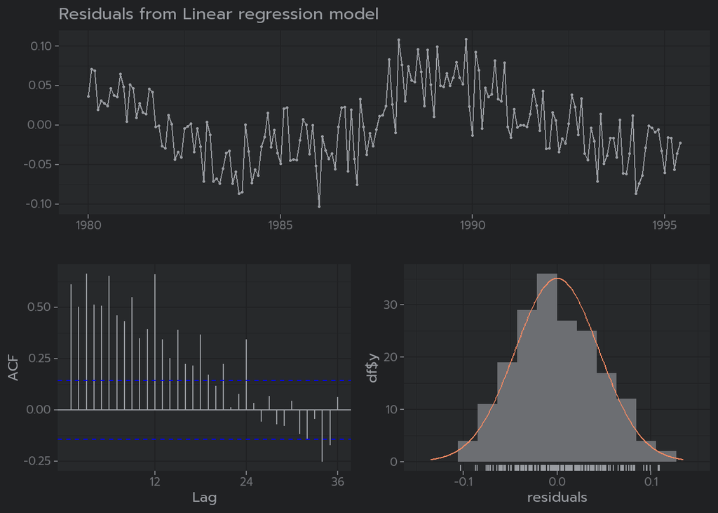

```
##
##  Breusch-Godfrey test for serial correlation of order up to 24
##
## data:  Residuals from Linear regression model
## LM test = 148.84, df = 24, p-value < 2.2e-16
```

```r
# Check residuals
checkresiduals(model.linear)
```

The linear regression model, using log(CPI) as the independent variable and log(Avg_Cost) as the dependent variable, demonstrates a robust positive correlation, as reflected by a high R-squared value (0.986). This indicates that log(CPI) accounts for a significant portion of the variance in log(Avg_Cost). However, the plot of the residuals from this model does not depict white noise, and discernible patterns are noticeable in the Autocorrelation Function (ACF) plot. This suggests that the residuals of our model are neither random nor uncorrelated.

### Question 3:

Use the auto.arima() function to fit an appropriate regression model with ARIMA errors to the Cost and CPI time series(i.e., CPI ➔ Independent variable, Cost➔ Dependent variable). Set the Order of seasonaldifferencing argument, D, to 1 and the ‘lambda’ argument to 0 to reflect a logarithmic transformation. 1. Use the summary() function to summarize the generated model. 2. Use the checkresiduals() function to evaluate the residuals. Discuss your results.

Ans:

1. Use the summary() function to summarize the generated model.

```r
model.aarima <- auto.arima(motel.ts[, 'Avg_Cost'], xreg = motel.ts[,'CPI'], seasonal = TRUE, D = 1, lambda = 0)

# Summarize the generated model
summary(model.aarima)
```

```
## Series: motel.ts[, "Avg_Cost"]
## Regression with ARIMA(0,1,1)(0,1,2)[12] errors
## Box Cox transformation: lambda= 0
##
## Coefficients:
##           ma1     sma1    sma2    xreg
##       -0.5516  -0.6160  0.1374  0.0099
## s.e.   0.0602   0.0785  0.1009  0.0025
##
## sigma^2 = 0.0003728:  log likelihood = 437.07
## AIC=-864.14   AICc=-863.79   BIC=-848.38
##
## Training set error measures:
##                     ME     RMSE       MAE       MPE     MAPE      MASE
## Training set -0.080122 1.307136 0.8968092 -0.112649 1.349787 0.2115032
##                     ACF1
## Training set -0.06269292
```

2. Use the checkresiduals() function to evaluate the residuals.

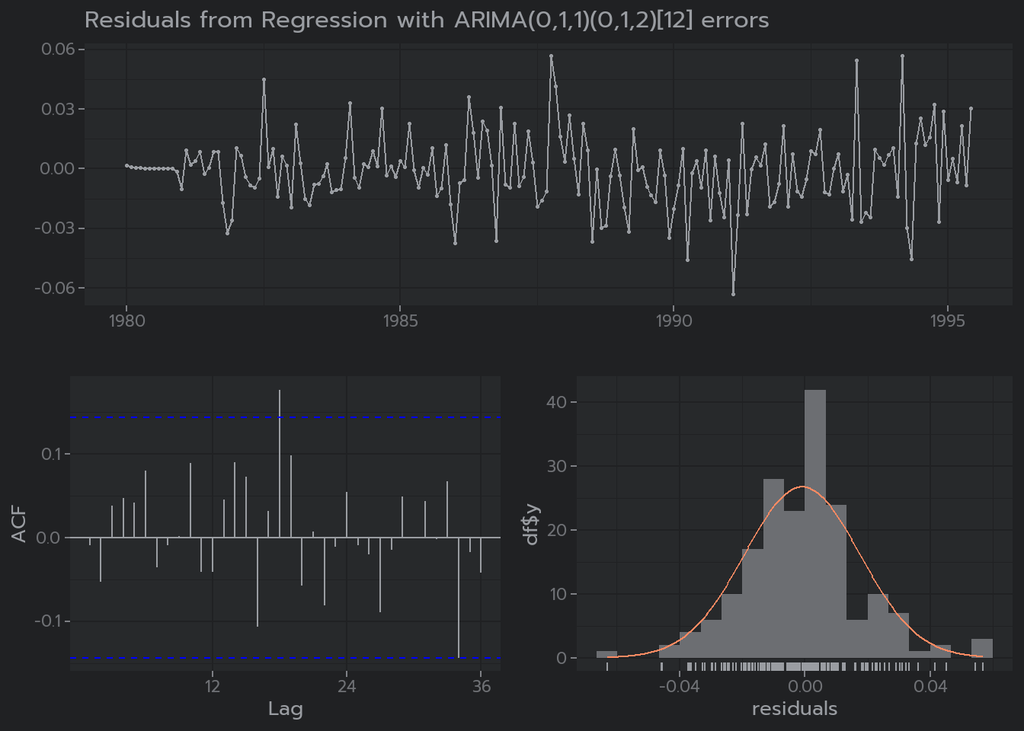

```
##
##  Ljung-Box test
##
## data:  Residuals from Regression with ARIMA(0,1,1)(0,1,2)[12] errors
## Q* = 22.342, df = 21, p-value = 0.3801
##
## Model df: 3.   Total lags used: 24
```

```r
# Check residuals
checkresiduals(model.aarima)
```

### Question 4:

1. Calculate and plot a naïve forecast of CPI for the next 18 months.
2. Forecast and plot the average price per room (i.e., Cost) for the next 18 months using the fitted model from Question 3 and the naïve forecast of CPI. Discuss your results.

Ans:

1. Calculate and plot a naïve forecast of CPI for the next 18 months.

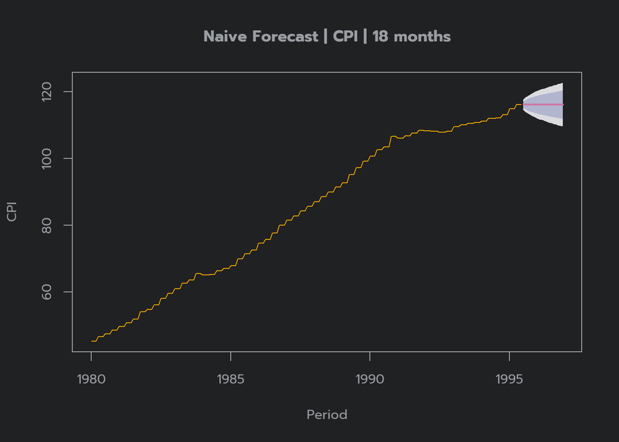

```r
model.naive <- naive(motel.ts[,"CPI"], h=18)

plot(model.naive, main= "Naive Forecast | CPI | 18 months", xlab= "Period", ylab="CPI")
```

2. Forecast and plot the average price per room (i.e., Cost) for the next 18 months using the fitted model from Question 3 and the naïve forecast of CPI.

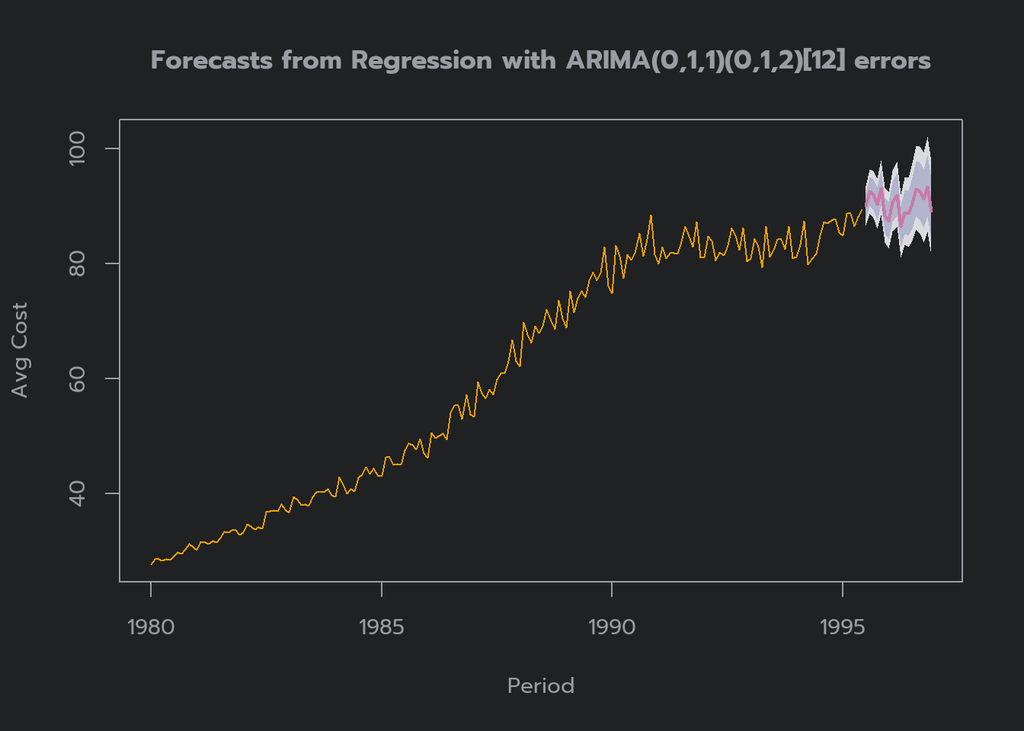

```r
forecast.avg <- forecast(model.aarima, h=18, xreg=(model.naive$mean))
plot(forecast.avg, xlab = "Period", ylab = "Avg Cost")
```

In the Naive Forecast, the CPI prediction remains unchanged throughout the 18 observations, whereas the forecast for the average room price shows variability, influenced by the ARIMA model’s error projections. This forecast appears to be well-grounded, exhibiting mean values that oscillate in a manner consistent with past data, along with stable variance and adherence to the existing trend. As the forecast extends into the future, the confidence interval broadens, indicating a reasonable and satisfactory predictive outcome.

### Question 5:

1. Use the VAR() function to fit a VAR(10) model to the $log(Cost)$ and $log(CPI)$ time series. Set the ‘type’ and ‘season’ arguments to ‘both’ and 12, respectively.
2. Forecast and plot the average price per room (i.e., Cost) and CPI for the next 18 months using your fitted model.
3. Plot the residuals’ ACF. Discuss your results.

Ans:

1. Use the VAR() function to fit a VAR(10) model to the log(CPI) and log(Cost) time series. Set the ‘type’ and ‘season’ arguments to ‘both’ and 12, respectively.

```r
var <- VAR(cbind(log(motel.ts[,'Avg_Cost']), log(motel.ts[,'CPI'])), p = 10, type = "both", season = 12)
summary(var)
```

```
##
## VAR Estimation Results:
## =========================
## Endogenous variables: log.motel.ts....Avg_Cost..., log.motel.ts....CPI...
## Deterministic variables: both
## Sample size: 176
## Log Likelihood: 1185.453
## Roots of the characteristic polynomial:
## 0.9752 0.9588 0.9588 0.9494 0.9494 0.8857 0.8857 0.8607 0.8607 0.858 0.858 0.7962 0.7962 0.7867 0.7765 0.7765 0.7244 0.7244 0.4201 0.4201
## Call:
## VAR(y = cbind(log(motel.ts[, "Avg_Cost"]), log(motel.ts[, "CPI"])),
##     p = 10, type = "both", season = 12L)
##
##
## Estimation results for equation log.motel.ts....Avg_Cost...:
## ============================================================
## log.motel.ts....Avg_Cost... = log.motel.ts....Avg_Cost....l1 + log.motel.ts....CPI....l1 + log.motel.ts....Avg_Cost....l2 + log.motel.ts....CPI....l2 + log.motel.ts....Avg_Cost....l3 + log.motel.ts....CPI....l3 + log.motel.ts....Avg_Cost....l4 + log.motel.ts....CPI....l4 + log.motel.ts....Avg_Cos…
##
##                                   Estimate Std. Error t value Pr(>|t|)
## log.motel.ts....Avg_Cost....l1   3.918e-01  8.566e-02   4.573 1.03e-05 ***
## log.motel.ts....CPI....l1        3.234e-02  3.326e-01   0.097  0.92268
## log.motel.ts....Avg_Cost....l2   2.361e-01  9.172e-02   2.574  0.01107 *
## log.motel.ts....CPI....l2        5.203e-01  4.448e-01   1.170  0.24403
## log.motel.ts....Avg_Cost....l3   2.619e-01  9.295e-02   2.818  0.00552 **
## log.motel.ts....CPI....l3       -3.801e-01  4.452e-01  -0.854  0.39463
## log.motel.ts....Avg_Cost....l4   6.684e-02  9.548e-02   0.700  0.48503
## log.motel.ts....CPI....l4        2.113e-01  4.446e-01   0.475  0.63539
## log.motel.ts....Avg_Cost....l5   1.064e-01  9.430e-02   1.128  0.26113
## log.motel.ts....CPI....l5       -7.446e-01  4.443e-01  -1.676  0.09596 .
## log.motel.ts....Avg_Cost....l6   1.080e-01  9.370e-02   1.153  0.25095
## log.motel.ts....CPI....l6        5.488e-01  4.524e-01   1.213  0.22715
## log.motel.ts....Avg_Cost....l7  -4.795e-02  9.377e-02  -0.511  0.60986
## log.motel.ts....CPI....l7       -1.154e-02  4.533e-01  -0.025  0.97972
## log.motel.ts....Avg_Cost....l8  -1.478e-01  9.248e-02  -1.598  0.11216
## log.motel.ts....CPI....l8       -5.395e-02  4.469e-01  -0.121  0.90407
## log.motel.ts....Avg_Cost....l9  -2.313e-02  9.246e-02  -0.250  0.80285
## log.motel.ts....CPI....l9        2.196e-01  4.515e-01   0.486  0.62744
## log.motel.ts....Avg_Cost....l10 -5.534e-03  8.677e-02  -0.064  0.94924
## log.motel.ts....CPI....l10      -2.696e-01  3.302e-01  -0.817  0.41554
## const                           -9.512e-02  1.711e-01  -0.556  0.57905
```

[output cut: 63 more lines]

```
## Residual standard error: 0.004535 on 143 degrees of freedom
## Multiple R-Squared: 0.9998,  Adjusted R-squared: 0.9997
## F-statistic: 1.855e+04 on 32 and 143 DF,  p-value: < 2.2e-16
##
##
##
## Covariance matrix of residuals:
##                             log.motel.ts....Avg_Cost... log.motel.ts....CPI...
## log.motel.ts....Avg_Cost...                   3.704e-04              1.699e-05
## log.motel.ts....CPI...                        1.699e-05              2.057e-05
##
## Correlation matrix of residuals:
##                             log.motel.ts....Avg_Cost... log.motel.ts....CPI...
## log.motel.ts....Avg_Cost...                      1.0000                 0.1947
## log.motel.ts....CPI...                           0.1947                 1.0000
```

```r
# Check out other models
VARselect(cbind(log(motel.ts[,'Avg_Cost']), log(motel.ts[,'CPI'])), lag.max = 10, type="both", season = 12)$selection
```

```
## AIC(n)  HQ(n)  SC(n) FPE(n)
##     10      4      4     10
```

We pick the lag order based on the AIC (Akaike Information Criterion) and thus proceed with p=10.

2. Forecast and plot the average price per room (i.e., Cost) and CPI for the next 18 months using your fitted model.

```r
pred <- predict(var, n.ahead = 18)

# Extract predicted CPI and Cost starting July 1995
CPI.pred <- ts(pred$fcst$log.motel.ts....CPI...[,1], st = c(1995, 7), fr = 12)
Avg_Cost.pred <- ts(pred$fcst$log.motel.ts....Avg_Cost...[,1], st = c(1995, 7), fr = 12)
```

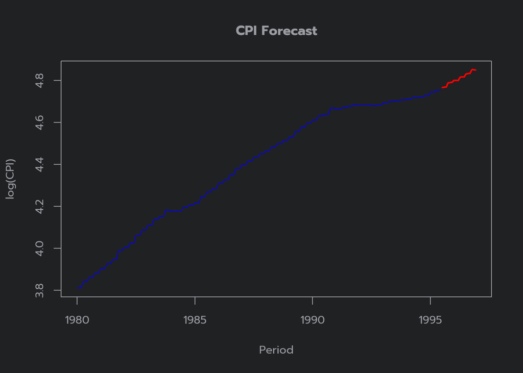

```r
# Plot predicted CPI
ts.plot(cbind(window(log(motel.ts[,'CPI']), start = c(1980)), CPI.pred), col = c("blue", "red"),
        lty = c(1, 1),
        lwd = c(1, 2), main = "CPI Forecast", ylab = "log(CPI)", xlab = "Period")
```

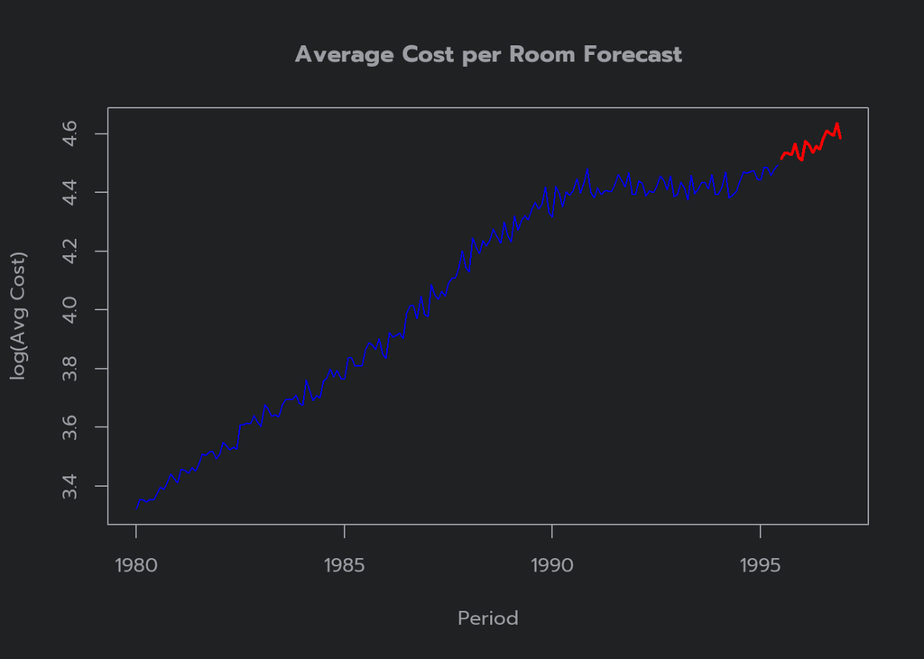

```r
ts.plot(cbind(window(log(motel.ts[,'Avg_Cost']), start = c(1980)), Avg_Cost.pred), col = c("blue", "red"),
        lty = c(1, 1),
        lwd = c(1, 2), main = "Average Cost per Room Forecast", ylab = "log(Avg Cost)", xlab = "Period")
```

3. Plot the residuals’ ACF.

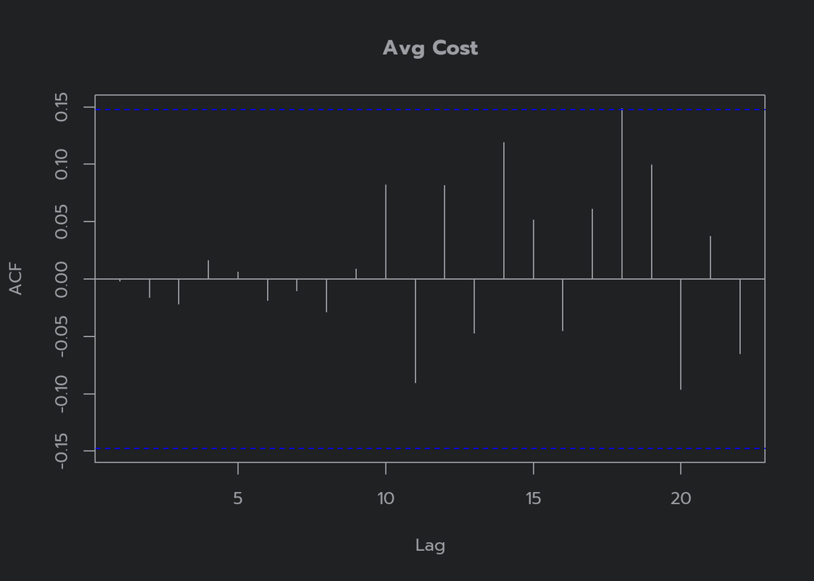

```r
acf(resid(var)[, 1], main='Avg Cost')
```

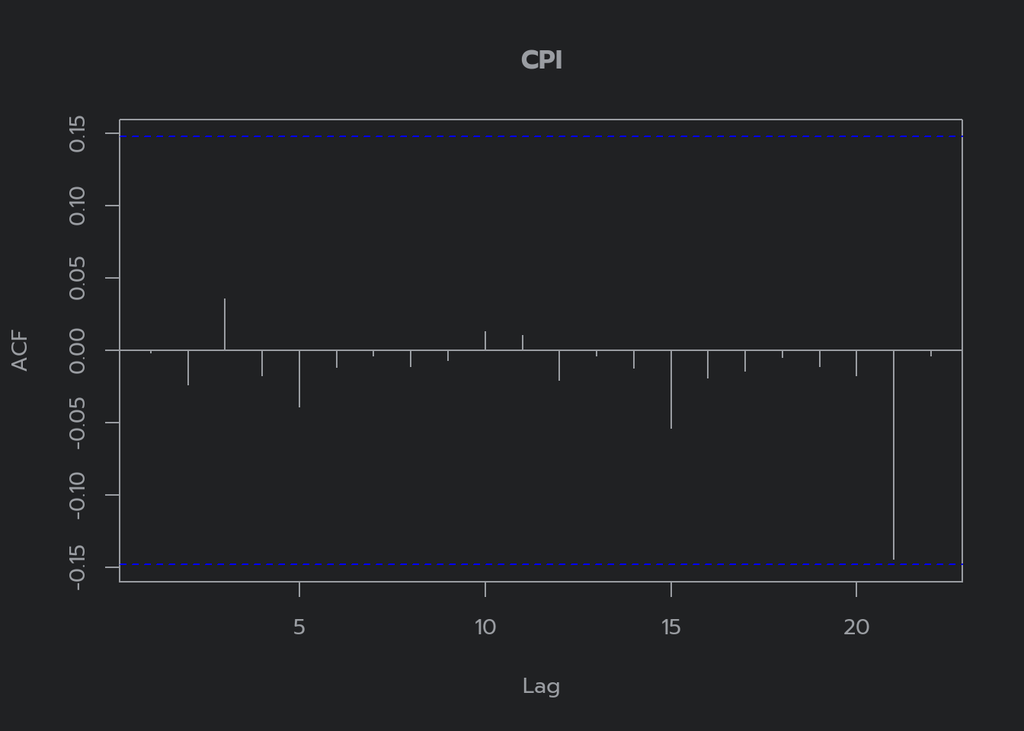

```r
acf(resid(var)[, 2], main='CPI')
```